# Predicting the Madness!!

Harvir Singh Virk, Yu Zhong, Yi-Cheng Lu

12/6/2020

##### import library

```r
library(dplyr)
library(data.table)
library(caret)
library(leaps)
library(glmnet)
library(tree)
library(stats)
library(factoextra)
library(randomForest)
library(gbm)
library(plyr)
library(car)
```

```r
library(ggcorrplot)
library(ggplot2)
library(grid)
library(gridExtra)
```

## Question 1: How do teams win?

### Step 1: Data cleaning

```r
seasonstats  <-read.csv("march-machine-learning-mania-2016-v2/RegularSeasonDetailedResults.csv")
tourneystats <-read.csv("march-machine-learning-mania-2016-v2/TourneyDetailedResults.csv")
tourneyseeds <-read.csv("march-machine-learning-mania-2016-v2/TourneySeeds.csv")
```

Converting column values

Based on the columns below. They have been translated to factors and confirmed to be factors.

```r
columnfactors = c("Season", "Daynum", "Wteam", "Lteam")
seasonstats[,columnfactors] = lapply(seasonstats[,columnfactors], factor)
seasonstats$Wloc = as.factor(seasonstats$Wloc)
sapply(seasonstats, class)
```

```
##    Season    Daynum     Wteam    Wscore     Lteam    Lscore      Wloc     Numot
##  "factor"  "factor"  "factor" "integer"  "factor" "integer"  "factor" "integer"
##      Wfgm      Wfga     Wfgm3     Wfga3      Wftm      Wfta       Wor       Wdr
## "integer" "integer" "integer" "integer" "integer" "integer" "integer" "integer"
##      Wast       Wto      Wstl      Wblk       Wpf      Lfgm      Lfga     Lfgm3
## "integer" "integer" "integer" "integer" "integer" "integer" "integer" "integer"
##     Lfga3      Lftm      Lfta       Lor       Ldr      Last       Lto      Lstl
## "integer" "integer" "integer" "integer" "integer" "integer" "integer" "integer"
##      Lblk       Lpf
## "integer" "integer"
```

```r
tourneystats[,columnfactors] = lapply(tourneystats[,columnfactors], factor)
tourneystats$Wloc = as.factor(tourneystats$Wloc)
sapply(tourneystats, class)
```

```
##    Season    Daynum     Wteam    Wscore     Lteam    Lscore      Wloc     Numot
##  "factor"  "factor"  "factor" "integer"  "factor" "integer"  "factor" "integer"
##      Wfgm      Wfga     Wfgm3     Wfga3      Wftm      Wfta       Wor       Wdr
## "integer" "integer" "integer" "integer" "integer" "integer" "integer" "integer"
##      Wast       Wto      Wstl      Wblk       Wpf      Lfgm      Lfga     Lfgm3
## "integer" "integer" "integer" "integer" "integer" "integer" "integer" "integer"
##     Lfga3      Lftm      Lfta       Lor       Ldr      Last       Lto      Lstl
## "integer" "integer" "integer" "integer" "integer" "integer" "integer" "integer"
##      Lblk       Lpf
## "integer" "integer"
```

Why – As of now, each ‘row’ represents a game. However, in order for us to judge who will win, we need each row to represent a team. So we need to double up the ‘rows’ so each row can represent the team. In our mind, the best approach was to create 2 dataframes, and then put them back together based on the winning or losing team representing the row.

```r
seasonstats.w = data.frame(seasonstats)
seasonstats.l = data.frame(seasonstats)

tourneystats.w = data.frame(tourneystats)
tourneystats.l = data.frame(tourneystats)
```

Now we are going to review column names for both new data frames and change them. We don’t really want a ‘winner’ and ‘loser’ breakdown. We want a breakdown just by the team and who the opponent is. We will have a variable in the future that will tabulate who the winner and loser is later on in the markdown.

```r
colnames(seasonstats.w)
```

```
##  [1] "Season" "Daynum" "Wteam"  "Wscore" "Lteam"  "Lscore" "Wloc"   "Numot"
##  [9] "Wfgm"   "Wfga"   "Wfgm3"  "Wfga3"  "Wftm"   "Wfta"   "Wor"    "Wdr"
## [17] "Wast"   "Wto"    "Wstl"   "Wblk"   "Wpf"    "Lfgm"   "Lfga"   "Lfgm3"
## [25] "Lfga3"  "Lftm"   "Lfta"   "Lor"    "Ldr"    "Last"   "Lto"    "Lstl"
## [33] "Lblk"   "Lpf"
```

```r
colnames(tourneystats.w)
```

```
##  [1] "Season" "Daynum" "Wteam"  "Wscore" "Lteam"  "Lscore" "Wloc"   "Numot"
##  [9] "Wfgm"   "Wfga"   "Wfgm3"  "Wfga3"  "Wftm"   "Wfta"   "Wor"    "Wdr"
## [17] "Wast"   "Wto"    "Wstl"   "Wblk"   "Wpf"    "Lfgm"   "Lfga"   "Lfgm3"
## [25] "Lfga3"  "Lftm"   "Lfta"   "Lor"    "Ldr"    "Last"   "Lto"    "Lstl"
## [33] "Lblk"   "Lpf"
```

We are changing the names for the ‘winner’ dataframe. We are changing the W’s to just regular ‘points’ or ‘assists’. The opponent will have an ‘o’ added in front of their statistics. Each team has 14 stats so their are a total of 28 name changes. However, we will be doing this for tourneystats as well.

```r
col_names_w = c("Season", "Daynum","Wteam","score","Lteam",
                "oscore","Wloc","Numot","fgm","fga","fgm3","fga3",
                "ftm","fta","or","dr","ast","to","stl","blk","pf",
                "ofgm","ofga","ofgm3","ofga3","oftm","ofta","oor",
                "odr","oast","oto","ostl","oblk","opf")
names(seasonstats.w) = col_names_w
names(tourneystats.w) = col_names_w

col_names_l = c("Season", "Daynum","Wteam","oscore","Lteam",
                "score","Wloc","Numot","ofgm","ofga","ofgm3","ofga3",
                "oftm","ofta","oor","odr","oast","oto","ostl","oblk","opf",
                "fgm","fga","fgm3","fga3","ftm","fta","or",
                "dr","ast","to","stl","blk","pf")
names(seasonstats.l) = col_names_l
names(tourneystats.l) = col_names_l
```

Starting with the winners stats. We will first create a column called ‘teams’. Eventually this + Season is where we will be joining the loser dataframe. We have also created another column called ‘scorediff’. We will be using this in our logistic regression. A value in the + means the team won. A value in the - means the team lost.

We will now duplicate that result for the losers as well. Another addition for seasonstats.l is switching the values for Wloc. Wloc means winners location. Since we want each value to be ‘per team’, I basically switched the values and made them the opposite of what the ‘winners’ dataframe has.

```r
seasonstats.w$Team = seasonstats.w$Wteam
seasonstats.w$scorediff = seasonstats.w$score - seasonstats.w$oscore

seasonstats.l$Team = seasonstats.l$Lteam
seasonstats.l$scorediff = seasonstats.l$score - seasonstats.l$oscore
seasonstats.l$Wloc = recode(seasonstats.l$Wloc, "'H'= 'A'; 'A' = 'H';else ='N'")

tourneystats.w$Team = tourneystats.w$Wteam
tourneystats.w$scorediff = tourneystats.w$score - tourneystats.w$oscore

tourneystats.l$Team = tourneystats.l$Lteam
tourneystats.l$scorediff = tourneystats.l$score - tourneystats.l$oscore
tourneystats.l$Wloc = recode(tourneystats.l$Wloc,  "'H'= 'A'; 'A' = 'H';else ='N'")
```

Now that we have the variables we need. We will do a merge to basically ‘double the rows’. Notice based on our ‘dim’ function our column values increase by 2 because of the variables we have feature engineered and our rows basically multiply by 2. A final check is the number of ‘scorediff’ that is less than 0 and greater than 0 are equal. This means our merge was a success as we have the losers and the winners put in together.

```r
seasonstats.clean = merge(seasonstats.l, seasonstats.w, all.x = TRUE, all.y = TRUE)
dim(seasonstats)
```

```
## [1] 71241    34
```

```r
dim(seasonstats.clean)
```

```
## [1] 142482     36
```

```r
sum(seasonstats.clean$scorediff < 0)
```

```
## [1] 71241
```

```r
sum(seasonstats.clean$scorediff > 0)
```

```
## [1] 71241
```

Doing the same with tourney

```r
tourneystats.clean = merge(tourneystats.l, tourneystats.w, all.x = TRUE, all.y = TRUE)
dim(tourneystats)
```

```
## [1] 847  34
```

```r
dim(tourneystats.clean)
```

```
## [1] 1694   36
```

```r
sum(tourneystats.clean$scorediff < 0)
```

```
## [1] 847
```

```r
sum(tourneystats.clean$scorediff > 0)
```

```
## [1] 847
```

We will be including tourney stats in this model to help make the winner prediction.

```r
df = merge(seasonstats.clean, tourneystats.clean, all.x = TRUE, all.y = TRUE)
dim(df)
```

```
## [1] 144176     36
```

Tourney seed was merged here. After a first pass at the analysis, tourney seed did not help any impact in this dataframe. It has been removed.

We have added a dependent variable named outcome that is between 0 and 1 and is dependent on scorediff.

```r
df$outcome <- ifelse(df$scorediff>0, 1, 0)
head(df[df$Team == 1328, ])
```

```
##      Season Daynum Wteam oscore Lteam score Wloc Numot ofgm ofga ofgm3 ofga3
## 2      2003     10  1104     68  1328    62    N     0   27   58     3    14
## 161    2003     18  1328     65  1414    87    H     0   23   50     8    13
## 279    2003     19  1328     63  1343    82    H     0   24   51     8    22
## 831    2003     26  1328     63  1341    75    H     0   24   45     5    15
## 1441   2003     33  1328     52  1216    92    H     0   15   48     5    17
## 1811   2003     40  1328     47  1164    69    H     0   16   44     5     8
##      oftm ofta oor odr oast oto ostl oblk opf fgm fga fgm3 fga3 ftm fta or dr
## 2      11   18  14  24   13  23    7    1  22  22  53    2   10  16  22 10 22
## 161    11   14  11  20   16  23    4    0  18  31  61    8   24  17  20 11 18
## 279     7   13   7  17   13  10    2    0  16  30  56    7   20  15  17 11 23
## 831    10   15   1  24    5  13    6    1  15  29  77   10   34   7  13 27 23
## 1441   17   25  11  18   10  21    5    2  21  32  66    8   18  20  25 18 29
## 1811   10   18   8  20   12  16    7    3  15  22  54    9   22  16  21 13 24
##      ast to stl blk pf Team scorediff outcome
## 2      8 18   9   2 20 1328        -6       0
## 161   20  9  15   1 16 1328        22       1
## 279   21 10   7   1 17 1328        19       1
## 831   15  9   6   0 15 1328        12       1
## 1441  17 10  16   3 21 1328        40       1
## 1811  15 11   8   5 18 1328        22       1
```

### Step 2: Exploratory analysis

```r
df = subset(df, select = -c(Season,Daynum, Wteam, Lteam, score, oscore, Numot, Team))
```

New corrplot to examine any high colinearity. The biggest ones are pf (personal foul) with ftm/oftm and fta/ofta which are free throws made and attempted by the team and the opponent.

```r
temp <- c("ofgm", "ofga", "ofgm3", "ofga3", "oftm", "ofta", "oor", "odr", "oast", "oto", "ostl", "oblk", "opf", "fgm", "fga", "fgm3", "fga3", "ftm", "fta", "or", "dr", "ast", "to", "stl", "blk", "pf")
df2 = df[temp]
df2[] <- lapply(df2, function(x) {
    if(is.factor(x)) as.numeric(as.character(x)) else x
})
sapply(df2, class)
```

```
##      ofgm      ofga     ofgm3     ofga3      oftm      ofta       oor       odr
## "integer" "integer" "integer" "integer" "integer" "integer" "integer" "integer"
##      oast       oto      ostl      oblk       opf       fgm       fga      fgm3
## "integer" "integer" "integer" "integer" "integer" "integer" "integer" "integer"
##      fga3       ftm       fta        or        dr       ast        to       stl
## "integer" "integer" "integer" "integer" "integer" "integer" "integer" "integer"
##       blk        pf
## "integer" "integer"
```

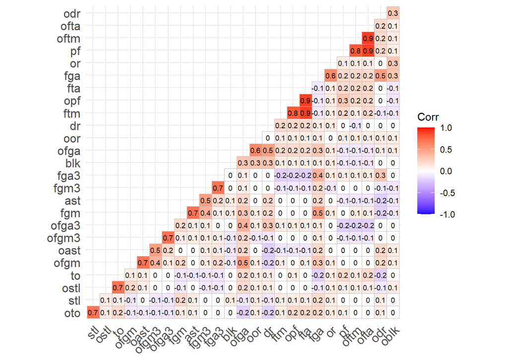

```r
corr <- round(cor(df2), 1)
ggcorrplot(corr, hc.order = TRUE, lab = TRUE, lab_size = 2.5, type = "lower")
```

Converting our dependent variable to a factor

```r
df$outcome = factor(df$outcome)
```

```r
completedataset = merge(seasonstats.clean, tourneystats.clean, all.x = TRUE, all.y = TRUE)
dim(completedataset)
```

```
## [1] 144176     36
```

```r
completedataset.clean = merge(completedataset, tourneyseeds, by = c("Season", "Team"), all.x = TRUE)
sum(is.na(completedataset.clean))
```

```
## [1] 113246
```

```r
completedataset.clean.noNAs = na.omit(completedataset.clean)
dim(completedataset.clean.noNAs)
```

```
## [1] 30930    37
```

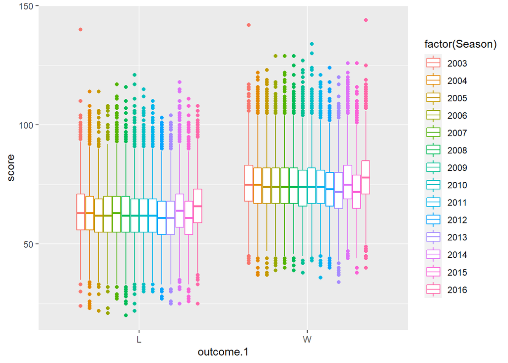

```r
completedataset.clean$outcome.1 = ifelse(completedataset.clean$scorediff>0, "W", "L")
ggplot(data = completedataset.clean, aes(x = outcome.1, y = score, colour = factor(Season))) +
  geom_boxplot(mapping = aes(x = outcome.1, y = score))
```

```r
  geom_jitter()
```

```
## geom_point: na.rm = FALSE
## stat_identity: na.rm = FALSE
## position_jitter
```

It seems that for winners, they tend to on average earn 10 more scores than the losing teams. Also, the scores average per year are roughly the same with a bit increase in recent years.

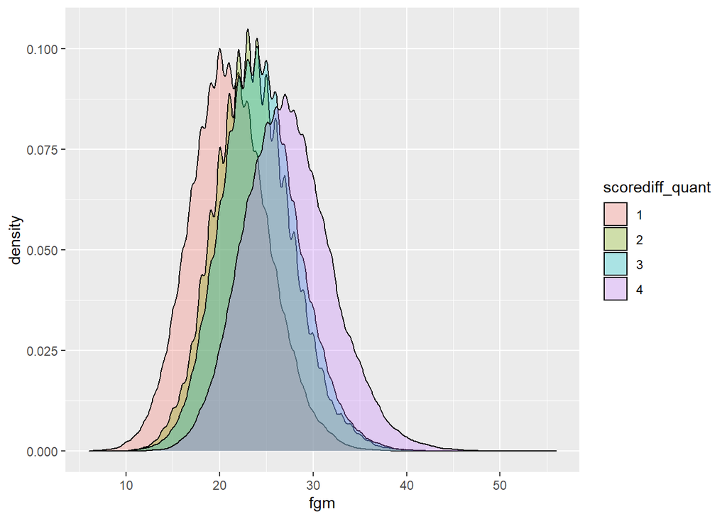

```r
temp = completedataset.clean
temp = temp %>%
        mutate(scorediff_quant = as.character(ntile(scorediff, 4)))


d =  ggplot(temp, aes(x = fgm, fill = scorediff_quant))
d + geom_density(aes(fill = scorediff_quant), alpha = 0.3)
```

From color 1-4 they represent teams with different number of winning field goals made. The larger the score difference, the more field goals made.

### Step 3: Variable selections

##### backword and forward variable analysis

Our initial analysis with logistic regression kept returning this error: glm.fit: algorithm did not convergeglm.fit: fitted probabilities numerically 0 or 1 occurred - after a brief search online and looking at our coefficients, it was determined our data was overfitting. We thought it would be best to do a quick regression on scorediff (variable highly like our dependent variable) to see if we can determine which one of our variables were most important.

We used the recommendation of stopping at 15

```r
regfit.bwd = regsubsets(scorediff~. - outcome, data = df, nvmax = 29, method = "backward")
regfit.fwd = regsubsets(scorediff~. - outcome, data = df, nvmax = 29 ,method = "forward")
summary(regfit.bwd)
```

```
## Subset selection object
## Call: regsubsets.formula(scorediff ~ . - outcome, data = df, nvmax = 29,
##     method = "backward")
## 28 Variables  (and intercept)
##       Forced in Forced out
## WlocH     FALSE      FALSE
## WlocN     FALSE      FALSE
## ofgm      FALSE      FALSE
## ofga      FALSE      FALSE
## ofgm3     FALSE      FALSE
## ofga3     FALSE      FALSE
## oftm      FALSE      FALSE
## ofta      FALSE      FALSE
## oor       FALSE      FALSE
## odr       FALSE      FALSE
## oast      FALSE      FALSE
## oto       FALSE      FALSE
## ostl      FALSE      FALSE
## oblk      FALSE      FALSE
## opf       FALSE      FALSE
## fgm       FALSE      FALSE
## fga       FALSE      FALSE
## fgm3      FALSE      FALSE
## fga3      FALSE      FALSE
## ftm       FALSE      FALSE
## fta       FALSE      FALSE
## or        FALSE      FALSE
## dr        FALSE      FALSE
## ast       FALSE      FALSE
## to        FALSE      FALSE
## stl       FALSE      FALSE
## blk       FALSE      FALSE
## pf        FALSE      FALSE
## 1 subsets of each size up to 28
## Selection Algorithm: backward
##           WlocH WlocN ofgm ofga ofgm3 ofga3 oftm ofta oor odr oast oto ostl
## 1  ( 1 )  " "   " "   "*"  " "  " "   " "   " "  " "  " " " " " "  " " " "
## 2  ( 1 )  " "   " "   "*"  " "  " "   " "   " "  " "  " " " " " "  " " " "
## 3  ( 1 )  " "   " "   "*"  " "  " "   " "   " "  " "  " " " " " "  " " " "
## 4  ( 1 )  " "   " "   "*"  " "  " "   " "   "*"  " "  " " " " " "  " " " "
```

[output cut: 38 more lines]

```
## 14  ( 1 ) "*"  " " "*" " " "*"  " "  "*" " " "*" " " " " "*" " " "*" " "
## 15  ( 1 ) "*"  " " "*" " " "*"  " "  "*" " " "*" " " "*" "*" " " "*" " "
## 16  ( 1 ) "*"  " " "*" " " "*"  " "  "*" " " "*" " " "*" "*" "*" "*" " "
## 17  ( 1 ) "*"  " " "*" " " "*"  " "  "*" " " "*" " " "*" "*" "*" "*" " "
## 18  ( 1 ) "*"  "*" "*" " " "*"  " "  "*" " " "*" " " "*" "*" "*" "*" " "
## 19  ( 1 ) "*"  "*" "*" " " "*"  " "  "*" " " "*" " " "*" "*" "*" "*" " "
## 20  ( 1 ) "*"  "*" "*" " " "*"  "*"  "*" " " "*" " " "*" "*" "*" "*" " "
## 21  ( 1 ) "*"  "*" "*" " " "*"  "*"  "*" " " "*" " " "*" "*" "*" "*" " "
## 22  ( 1 ) "*"  "*" "*" " " "*"  "*"  "*" "*" "*" " " "*" "*" "*" "*" " "
## 23  ( 1 ) "*"  "*" "*" " " "*"  "*"  "*" "*" "*" " " "*" "*" "*" "*" "*"
## 24  ( 1 ) "*"  "*" "*" " " "*"  "*"  "*" "*" "*" " " "*" "*" "*" "*" "*"
## 25  ( 1 ) "*"  "*" "*" " " "*"  "*"  "*" "*" "*" " " "*" "*" "*" "*" "*"
## 26  ( 1 ) "*"  "*" "*" " " "*"  "*"  "*" "*" "*" " " "*" "*" "*" "*" "*"
## 27  ( 1 ) "*"  "*" "*" " " "*"  "*"  "*" "*" "*" "*" "*" "*" "*" "*" "*"
## 28  ( 1 ) "*"  "*" "*" "*" "*"  "*"  "*" "*" "*" "*" "*" "*" "*" "*" "*"
```

```r
summary(regfit.fwd)
```

```
## Subset selection object
## Call: regsubsets.formula(scorediff ~ . - outcome, data = df, nvmax = 29,
##     method = "forward")
## 28 Variables  (and intercept)
##       Forced in Forced out
## WlocH     FALSE      FALSE
## WlocN     FALSE      FALSE
## ofgm      FALSE      FALSE
## ofga      FALSE      FALSE
## ofgm3     FALSE      FALSE
## ofga3     FALSE      FALSE
## oftm      FALSE      FALSE
## ofta      FALSE      FALSE
## oor       FALSE      FALSE
## odr       FALSE      FALSE
## oast      FALSE      FALSE
## oto       FALSE      FALSE
## ostl      FALSE      FALSE
## oblk      FALSE      FALSE
## opf       FALSE      FALSE
## fgm       FALSE      FALSE
## fga       FALSE      FALSE
## fgm3      FALSE      FALSE
## fga3      FALSE      FALSE
## ftm       FALSE      FALSE
## fta       FALSE      FALSE
## or        FALSE      FALSE
## dr        FALSE      FALSE
## ast       FALSE      FALSE
## to        FALSE      FALSE
## stl       FALSE      FALSE
## blk       FALSE      FALSE
## pf        FALSE      FALSE
## 1 subsets of each size up to 28
## Selection Algorithm: forward
##           WlocH WlocN ofgm ofga ofgm3 ofga3 oftm ofta oor odr oast oto ostl
## 1  ( 1 )  " "   " "   "*"  " "  " "   " "   " "  " "  " " " " " "  " " " "
## 2  ( 1 )  " "   " "   "*"  " "  " "   " "   " "  " "  " " " " " "  " " " "
## 3  ( 1 )  " "   " "   "*"  " "  " "   " "   " "  " "  " " " " " "  " " " "
## 4  ( 1 )  " "   " "   "*"  " "  " "   " "   "*"  " "  " " " " " "  " " " "
```

[output cut: 38 more lines]

```
## 14  ( 1 ) "*"  " " "*" " " "*"  " "  "*" " " "*" " " " " "*" " " "*" " "
## 15  ( 1 ) "*"  " " "*" " " "*"  " "  "*" " " "*" " " "*" "*" " " "*" " "
## 16  ( 1 ) "*"  " " "*" " " "*"  " "  "*" " " "*" " " "*" "*" "*" "*" " "
## 17  ( 1 ) "*"  " " "*" " " "*"  " "  "*" " " "*" " " "*" "*" "*" "*" " "
## 18  ( 1 ) "*"  " " "*" " " "*"  "*"  "*" " " "*" " " "*" "*" "*" "*" " "
## 19  ( 1 ) "*"  " " "*" " " "*"  "*"  "*" " " "*" " " "*" "*" "*" "*" " "
## 20  ( 1 ) "*"  "*" "*" " " "*"  "*"  "*" " " "*" " " "*" "*" "*" "*" " "
## 21  ( 1 ) "*"  "*" "*" " " "*"  "*"  "*" " " "*" " " "*" "*" "*" "*" " "
## 22  ( 1 ) "*"  "*" "*" " " "*"  "*"  "*" "*" "*" " " "*" "*" "*" "*" " "
## 23  ( 1 ) "*"  "*" "*" " " "*"  "*"  "*" "*" "*" " " "*" "*" "*" "*" "*"
## 24  ( 1 ) "*"  "*" "*" " " "*"  "*"  "*" "*" "*" " " "*" "*" "*" "*" "*"
## 25  ( 1 ) "*"  "*" "*" " " "*"  "*"  "*" "*" "*" " " "*" "*" "*" "*" "*"
## 26  ( 1 ) "*"  "*" "*" " " "*"  "*"  "*" "*" "*" " " "*" "*" "*" "*" "*"
## 27  ( 1 ) "*"  "*" "*" " " "*"  "*"  "*" "*" "*" "*" "*" "*" "*" "*" "*"
## 28  ( 1 ) "*"  "*" "*" "*" "*"  "*"  "*" "*" "*" "*" "*" "*" "*" "*" "*"
```

```r
coef(regfit.bwd, 15)
```

```
##   (Intercept)          ofgm          ofga         ofgm3          oftm
##  6.398684e-13 -2.000000e+00 -1.422022e-14 -1.000000e+00 -1.000000e+00
##          oast           oto          ostl          oblk           fgm
## -1.328992e-14 -3.772135e-14 -2.346103e-14  1.515850e-14  2.000000e+00
##          fgm3           ftm            or           ast            to
##  1.000000e+00  1.000000e+00 -1.387380e-14 -9.545450e-15 -2.234763e-14
##           blk
##  1.392930e-14
```

```r
coef(regfit.fwd, 15)
```

```
##   (Intercept)          ofgm          ofga         ofgm3          oftm
##  6.527729e-13 -2.000000e+00 -1.393618e-14 -1.000000e+00 -1.000000e+00
##          oast           oto          ostl          oblk           fgm
## -1.336441e-14 -3.710095e-14 -2.349586e-14  1.498778e-14  2.000000e+00
##          fgm3           ftm            or           ast            to
##  1.000000e+00  1.000000e+00 -1.386635e-14 -9.600848e-15 -2.286066e-14
##           blk
##  1.388224e-14
```

##### Variable selections with lasso regression

```r
set.seed(19910401)
inTrain = createDataPartition(df$outcome, p = 0.75, list = FALSE)
dfTrain = df[inTrain,]
dfTest = df[-inTrain,]
```

Creating x and y

```r
x = model.matrix(outcome~. - scorediff, dfTrain)[, -1]
y = dfTrain$outcome
xval = model.matrix(outcome~. - scorediff, dfTest)[, -1]
yval = dfTest$outcome
```

Running lasso

```r
lassotrain = glmnet(x, y, family = "binomial", alpha = 1, lambda = NULL)
```

plotting the lasso

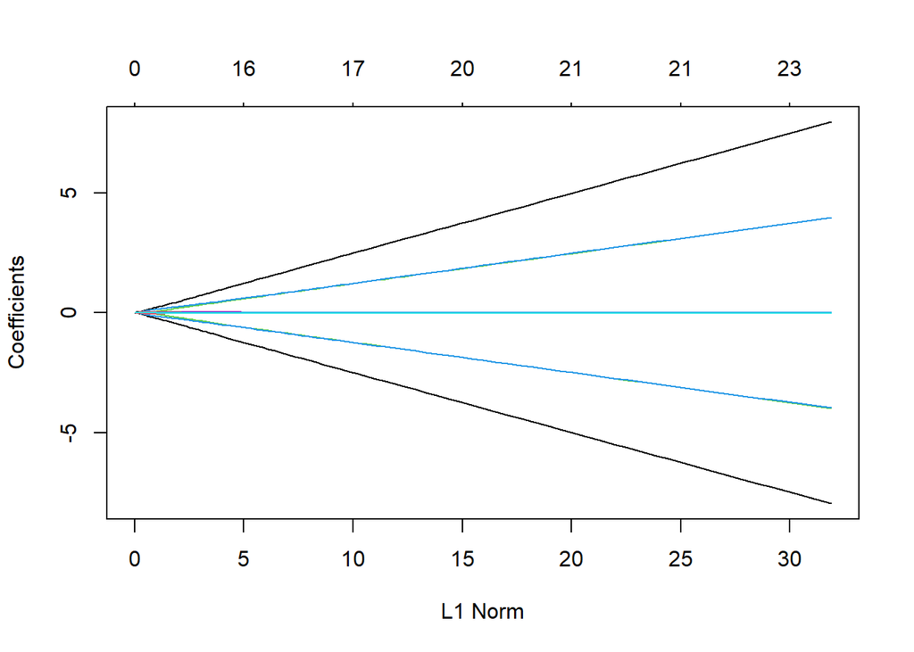

```r
plot(lassotrain)
```

using cross validation for lasso. This could take up to 10 minutes but will help us in the long run

```r
set.seed(956)
crossval = cv.glmnet(x, y, family = "binomial", alpha =1)
```

Now confirming which variables are best.

```r
bestlam = crossval$lambda.min
out = glmnet(xval, yval, family = "binomial", alpha = 1)
lasso.coef = predict(out, type = "coefficients", s = bestlam)[1:29,]
lasso.coef
```

```
##   (Intercept)         WlocH         WlocN          ofgm          ofga
## -1.926724e-01  0.000000e+00  0.000000e+00 -7.894416e+00  0.000000e+00
##         ofgm3         ofga3          oftm          ofta           oor
## -3.929692e+00  0.000000e+00 -3.929273e+00 -1.220072e-02  0.000000e+00
##           odr          oast           oto          ostl          oblk
## -8.082073e-05 -1.754355e-04  0.000000e+00 -1.200344e-02  0.000000e+00
##           opf           fgm           fga          fgm3          fga3
##  2.231846e-02  7.889984e+00 -2.680719e-04  3.961909e+00  0.000000e+00
##           ftm           fta            or            dr           ast
##  3.927713e+00  1.249188e-02  0.000000e+00  8.262507e-03  0.000000e+00
##            to           stl           blk            pf
## -5.949467e-03  0.000000e+00  0.000000e+00 -1.757742e-02
```

These variables are also the 6 best variables based on the forward and backword regression models. Which makes sense, scoring more than ones opponent does make one the winner.

### step 4: Model fits

##### creating a training and testing dataset

```r
set.seed(19910401)
inTrain = createDataPartition(df$outcome, p = 0.75, list = FALSE)
dfTrain = df[inTrain,]
dfTest = df[-inTrain,]
```

##### Logistic regression with all variables

We tried with several type of glm models with different variables. Some of them work, some of them don’t. Below are all of the results

```r
glm.fits = glm(outcome ~. - scorediff, data = dfTrain, family = binomial)
```

If all variables are included, the data is overfit. However, our recall and precision are perfect if all variables are used. In my opinion, this is not the best model to use.

```r
summary(glm.fits)
```

```
##
## Call:
## glm(formula = outcome ~ . - scorediff, family = binomial, data = dfTrain)
##
## Deviance Residuals:
##        Min          1Q      Median          3Q         Max
## -1.261e-04  -2.100e-08   0.000e+00   2.100e-08   1.110e-04
##
## Coefficients:
##               Estimate Std. Error z value Pr(>|z|)
## (Intercept)  3.291e-02  1.520e+03   0.000    1.000
## WlocH       -2.465e-02  3.258e+02   0.000    1.000
## WlocN       -1.481e-02  4.538e+02   0.000    1.000
## ofgm        -3.875e+01  3.037e+02  -0.128    0.898
## ofga         7.119e-02  1.230e+02   0.001    1.000
## ofgm3       -1.936e+01  1.640e+02  -0.118    0.906
## ofga3       -1.530e-03  4.424e+01   0.000    1.000
## oftm        -1.937e+01  1.646e+02  -0.118    0.906
## ofta         2.457e-02  8.465e+01   0.000    1.000
## oor         -5.737e-02  1.264e+02   0.000    1.000
## odr          1.757e-02  1.033e+02   0.000    1.000
## oast         5.911e-04  4.790e+01   0.000    1.000
## oto          3.725e-02  9.002e+01   0.000    1.000
## ostl        -1.172e-02  7.231e+01   0.000    1.000
## oblk        -3.616e-03  7.130e+01   0.000    1.000
## opf          5.874e-03  7.101e+01   0.000    1.000
## fgm          3.874e+01  3.026e+02   0.128    0.898
## fga         -5.512e-02  1.210e+02   0.000    1.000
## fgm3         1.934e+01  1.640e+02   0.118    0.906
## fga3         1.540e-03  4.484e+01   0.000    1.000
## ftm          1.936e+01  1.639e+02   0.118    0.906
## fta         -1.773e-02  8.388e+01   0.000    1.000
## or           4.037e-02  1.235e+02   0.000    1.000
## dr          -3.618e-02  1.061e+02   0.000    1.000
## ast          5.498e-03  4.738e+01   0.000    1.000
## to          -3.193e-02  9.030e+01   0.000    1.000
## stl          1.284e-02  7.212e+01   0.000    1.000
## blk          6.712e-03  7.185e+01   0.000    1.000
## pf          -6.108e-03  7.008e+01   0.000    1.000
##
## (Dispersion parameter for binomial family taken to be 1)
##
##     Null deviance: 1.4990e+05  on 108131  degrees of freedom
## Residual deviance: 3.7384e-05  on 108103  degrees of freedom
## AIC: 58
##
## Number of Fisher Scoring iterations: 25
```

```r
outcome.test = dfTest$outcome
```

```r
glm.probs = predict(glm.fits, dfTest, type = "response")
glm.probs = ifelse(glm.probs > .5, 1, 0)
glm.table = table(glm.probs, outcome.test)
glm.table
```

```
##          outcome.test
## glm.probs     0     1
##         0 18022     0
##         1     0 18022
```

```r
precision(glm.table)
```

```
## [1] 1
```

```r
recall(glm.table)
```

```
## [1] 1
```

```r
mean(glm.probs == outcome.test)
```

```
## [1] 1
```

##### Logistic regression with top 6 variables

```r
glm.fits2 = glm(outcome ~ ofgm + fgm + ftm + oftm + ofgm3 + fgm3, data = dfTrain, family = binomial)
summary(glm.fits2)
```

```
##
## Call:
## glm(formula = outcome ~ ofgm + fgm + ftm + oftm + ofgm3 + fgm3,
##     family = binomial, data = dfTrain)
##
## Deviance Residuals:
##        Min          1Q      Median          3Q         Max
## -9.412e-05  -2.100e-08   0.000e+00   2.100e-08   9.416e-05
##
## Coefficients:
##              Estimate Std. Error z value Pr(>|z|)
## (Intercept)   0.03508  912.03531   0.000    1.000
## ofgm        -38.73411  281.54216  -0.138    0.891
## fgm          38.73613  281.61080   0.138    0.891
## ftm          19.37179  141.11779   0.137    0.891
## oftm        -19.37193  141.13351  -0.137    0.891
## ofgm3       -19.37214  149.49233  -0.130    0.897
## fgm3         19.35953  149.51876   0.129    0.897
##
## (Dispersion parameter for binomial family taken to be 1)
##
##     Null deviance: 1.4990e+05  on 108131  degrees of freedom
## Residual deviance: 3.7582e-05  on 108125  degrees of freedom
## AIC: 14
##
## Number of Fisher Scoring iterations: 25
```

```r
glm.probs2 = predict(glm.fits2, dfTest, type = "response")
glm.probs2 = ifelse(glm.probs2 > .5, 1, 0)
glm.table2 = table(glm.probs2, outcome.test)
glm.table2
```

```
##           outcome.test
## glm.probs2     0     1
##          0 18022     0
##          1     0 18022
```

```r
precision(glm.table2)
```

```
## [1] 1
```

```r
recall(glm.table2)
```

```
## [1] 1
```

```r
mean(glm.probs2 == outcome.test)
```

```
## [1] 1
```

##### Logistic regression with 3 variables

As one can see, even the top 6 variables are just too powerful and lead to predicting the model perfectly. We would have to limit our model to ofgm, fgm, and ftm to get a result that is not perfect.

```r
glm.fits3 = glm(outcome ~ ofgm + fgm + ftm, data = dfTrain, family = binomial)
summary(glm.fits3)
```

```
##
## Call:
## glm(formula = outcome ~ ofgm + fgm + ftm, family = binomial,
##     data = dfTrain)
##
## Deviance Residuals:
##     Min       1Q   Median       3Q      Max
## -3.9267  -0.5245  -0.0002   0.5386   3.0086
##
## Coefficients:
##              Estimate Std. Error z value Pr(>|z|)
## (Intercept) -2.951045   0.062211  -47.44   <2e-16 ***
## ofgm        -0.488078   0.003382 -144.30   <2e-16 ***
## fgm          0.461328   0.003250  141.96   <2e-16 ***
## ftm          0.247460   0.001915  129.25   <2e-16 ***
## ---
## Signif. codes:  0 '***' 0.001 '**' 0.01 '*' 0.05 '.' 0.1 ' ' 1
##
## (Dispersion parameter for binomial family taken to be 1)
##
##     Null deviance: 149903  on 108131  degrees of freedom
## Residual deviance:  78038  on 108128  degrees of freedom
## AIC: 78046
##
## Number of Fisher Scoring iterations: 6
```

```r
glm.probs3 = predict(glm.fits3, dfTest, type = "response")
glm.probs3 = ifelse(glm.probs3 > .5, 1, 0)
glm.table3 = table(glm.probs3, outcome.test)
glm.table3
```

```
##           outcome.test
## glm.probs3     0     1
##          0 14969  3116
##          1  3053 14906
```

```r
precision(glm.table3)
```

```
## [1] 0.8277025
```

```r
recall(glm.table3)
```

```
## [1] 0.8305959
```

```r
mean(glm.probs3 == outcome.test)
```

```
## [1] 0.8288481
```

In our opinion, logistic regression did it’s job and figured out the best way to figure out who wins a game is to figure out who scores the most. Unfortunately this is a bit underwhelming speaking statistically. We tried running the knn here but it failed to work after 30 minutes. So we stopped and conducted other analyses.

##### Decision tree

We will now conduct a decision tree. We wanted to keep all the variables to see how the decision tree would choose it’s variables

```r
set.seed(19910401)

bbtree = tree(outcome ~. -scorediff, dfTrain)
tree.pred = predict(bbtree, dfTest, type = "class")
treetable = table(tree.pred, outcome.test)
treetable
```

```
##          outcome.test
## tree.pred     0     1
##         0 12866  4407
##         1  5156 13615
```

As you can see above, this tree has some error rate.

```r
precision(treetable)
```

```
## [1] 0.7448619
```

```r
recall(treetable)
```

```
## [1] 0.7139052
```

The tree doesn’t perform as well as logistic regression. The precision and recall aren’t as great.

```r
cv.bbtree = cv.tree(bbtree, FUN = prune.misclass)
```

Cross validating the tree

```r
cv.bbtree$size[which.min(cv.bbtree$dev)]
```

```
## [1] 8
```

The results say a tree size of 8 performs best.

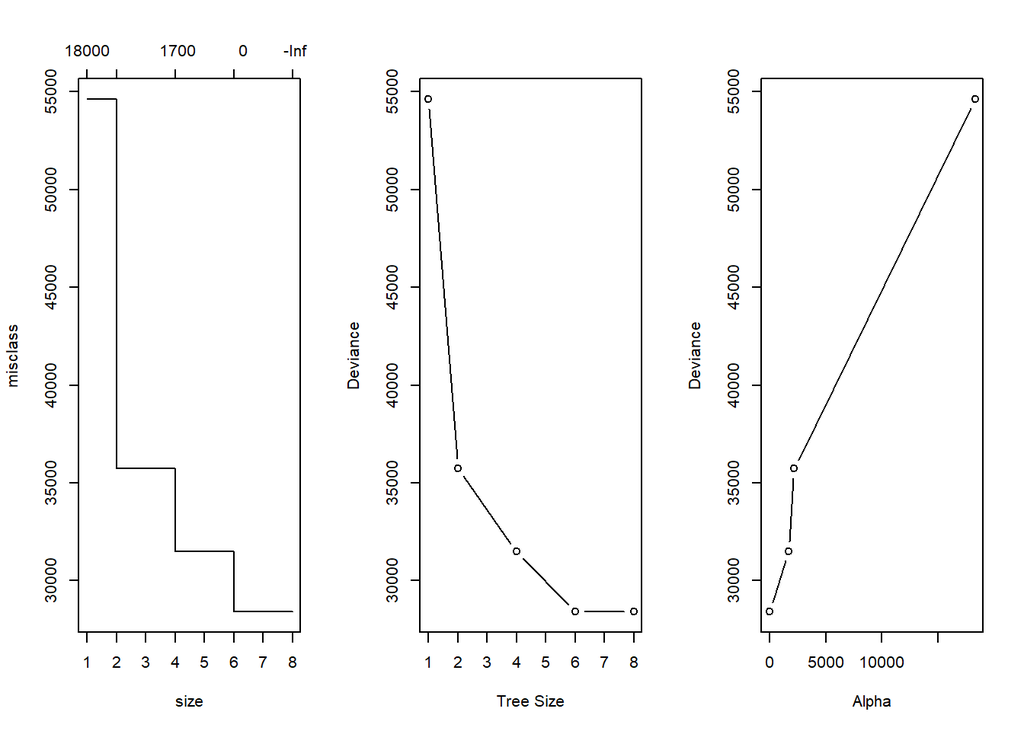

```r
par(mfrow = c(1,3))
plot(cv.bbtree)
plot(cv.bbtree$size, cv.bbtree$dev, type="b",
     xlab = "Tree Size", ylab = "Deviance")
plot(cv.bbtree$k, cv.bbtree$dev, type = "b",
     xlab = "Alpha", ylab = "Deviance")
```

Based on the ‘tree size’ graph above. 6 and 8 tree size perform equally well.

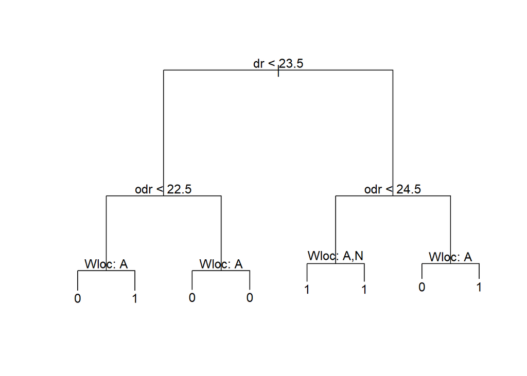

```r
best_tree_size=8

par(mfrow = c(1,1))
prune.bb <- prune.misclass(bbtree, best = best_tree_size)
plot(prune.bb)
text(prune.bb, pretty=0)
```

With 8, we have 2 specific leaves that don’t change on either answer

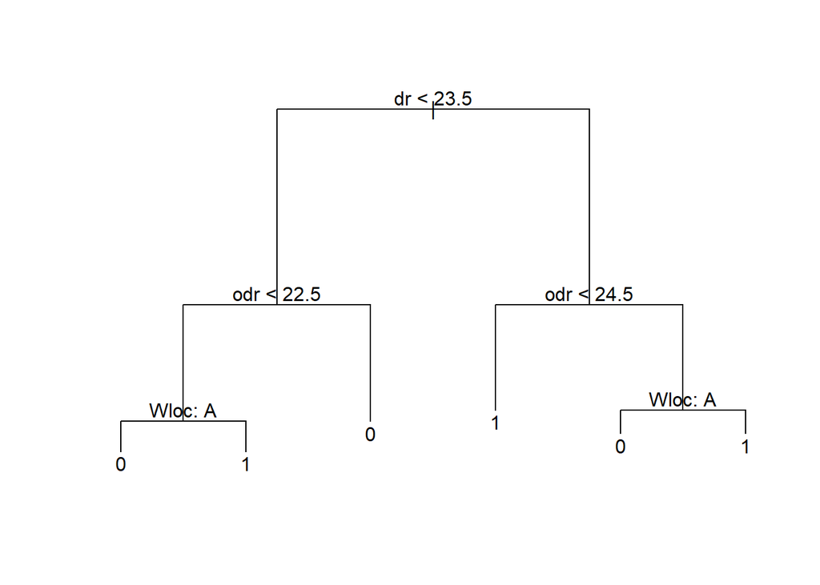

```r
best_tree_size=6

par(mfrow = c(1,1))
prune.bb <- prune.misclass(bbtree, best = best_tree_size)
plot(prune.bb)
text(prune.bb, pretty=0)
```

Tree size 6 is our best answer. These are also variables that weren’t picked up by our variable selection. These make our analysis more interesting but less powerful.

Teams - This dataset will need to be merged as well but is a much lower priority. It basically gives us team names. It will not matter for our predictions as the teams are coded by numbers. We have included it in the Markdown and HTML printout for your confirmation purposes.

Seasons - We are also ignoring this dataset for now. Though we originally included it in our proposal, it adds no impact on our prediction. It basically explains the ‘Seed’ a bit more. We have included it in the Markdown and HTML printout for your confirmation purposes.

TourneySlots. Not used

## Question 1.2: How do teams win? Analyze with aggregated yearly data

For the following data, each row represents each team each year’s performance. Each column represents the average of performance(like field goals made, 3 pointers..) within that year.

### Step 1: Data cleaning

##### Extract dataset

```r
seasonstats  <-read.csv("march-machine-learning-mania-2016-v2/RegularSeasonDetailedResults.csv")
tourneystats <-read.csv("march-machine-learning-mania-2016-v2/TourneyDetailedResults.csv")
teams <- read.csv('march-machine-learning-mania-2016-v2/Teams.csv')

wreg_detail_0315 <- seasonstats %>%
  select(Season, Wteam,Lteam,
         Wloc,Wscore,Numot, Wfgm,Wfga,Wfgm3,
         Wfga3,Wftm,Wfta,Wor,Wdr,Wast, Wto,Wstl, Wblk, Wpf)%>%
  filter(Season>=2003, Season <=2015)

lreg_detail_0315 <- seasonstats %>%
  select(Season, Wteam,Lteam,
         Wloc,Lscore,Numot, Lfgm,Lfga,Lfgm3,
         Lfga3,Lftm,Lfta,Lor,Ldr,Last, Lto,Lstl, Lblk, Lpf)%>%
  filter(Season>=2003, Season <=2015)
```

##### Extract winner record

```r
win_record <- function(data){
  winrecord = rbind()
  for (i in unique(data$Season)){
    yearly_data <-  data %>%
      filter(Season == i)
    for (team in teams$Team_Id) {
      num_wins <- length(which(yearly_data$Wteam == team))
      num_lose <- length(which(yearly_data$Lteam == team))
      win_rate <- num_wins / (num_wins+num_lose)


      details <- yearly_data[which(
        yearly_data$Wteam == team),]

  #get details about location when winning
  h.win <- length(which(details$Wloc == "H"))
  a.win <- length(which(details$Wloc == "A"))
  n.win <- length(which(details$Wloc == "N"))

  #get the statistics of winning games
  stats <- transpose(as.data.frame(colMeans(details[,5:19])))

  #put them together
  single_team <-  cbind(team, i, num_wins, num_lose, win_rate,h.win, a.win,n.win,stats)

  winrecord <- rbind(winrecord,single_team)


    }
  }
  names(winrecord) <-c('team','year','num_wins','num_lose',
                       'win_rate','h.win','a.win','n.win',
                       names(wreg_detail_0315)[5:19])
  return(winrecord)
}
```

##### Extract lose record

```r
lose_record <- function(data){
  loserecord = rbind()
  for (i in unique(data$Season)){
    yearly_data <-  data %>%
      filter(Season == i)
    for (team in teams$Team_Id) {
      num_wins <- length(which(yearly_data$Wteam == team))
      num_lose <- length(which(yearly_data$Lteam == team))
      lose_rate <- num_lose / (num_wins+num_lose)


      details <- yearly_data[which(
        yearly_data$Lteam == team),]

  #get details about location when winning
  h.win <- length(which(details$Wloc == "A"))
  a.win <- length(which(details$Wloc == "H"))
  n.win <- length(which(details$Wloc == "N"))

  #get the statistics of winning games
  stats <- transpose(as.data.frame(colMeans(details[,5:19])))

  #put them together
  single_team <-  cbind(team, i, num_wins, num_lose, lose_rate,h.win, a.win,n.win,stats)

  loserecord <- rbind(loserecord,single_team)


    }
  }
  names(loserecord) <-c('team','year','num_wins','num_lose',
                       'lose_rate','h.win','a.win','n.win',
                       names(lreg_detail_0315)[5:19])
  return(loserecord)
}
```

##### Apply to all data

```r
reg_winrecord   <-  win_record(wreg_detail_0315)
reg_loserecord  <- lose_record(lreg_detail_0315)
```

##### Deal with NAs

```r
reg_winrecord <- na.omit(reg_winrecord)
reg_loserecord <- na.omit(reg_loserecord)
head(reg_winrecord)
```

```
##   team year num_wins num_lose  win_rate h.win a.win n.win   Wscore      Numot
## 2 1102 2003       12       16 0.4285714     9     3     0 68.75000 0.00000000
## 3 1103 2003       13       14 0.4814815     9     4     0 87.76923 0.30769231
## 4 1104 2003       17       11 0.6071429    13     1     3 74.70588 0.05882353
## 5 1105 2003        7       19 0.2692308     5     2     0 79.42857 0.00000000
## 6 1106 2003       13       15 0.4642857     8     5     0 68.30769 0.07692308
## 7 1107 2003        7       21 0.2500000     5     2     0 70.28571 0.42857143
##       Wfgm     Wfga     Wfgm3    Wfga3     Wftm     Wfta       Wor      Wdr
## 2 22.58333 40.00000 10.000000 21.58333 13.58333 20.75000  3.833333 19.33333
## 3 30.00000 55.38462  5.461538 14.38462 22.30769 30.92308  9.384615 21.46154
## 4 25.82353 58.35294  7.058824 20.82353 16.00000 22.52941 13.529412 26.41176
## 5 25.57143 61.85714  9.142857 22.42857 19.14286 25.71429 14.571429 25.85714
## 6 24.76923 53.84615  5.846154 15.92308 12.92308 20.76923 12.769231 28.00000
## 7 25.00000 55.71429  8.000000 21.00000 12.28571 15.85714  8.714286 25.00000
##       Wast      Wto      Wstl     Wblk      Wpf
## 2 16.91667 11.08333  7.333333 2.833333 16.08333
## 3 17.69231 12.53846  7.307692 1.846154 20.46154
## 4 14.00000 13.05882  7.235294 4.176471 16.47059
## 5 15.85714 18.00000 11.285714 2.000000 19.42857
## 6 13.00000 17.69231  9.384615 3.769231 18.38462
## 7 11.28571 13.00000  6.000000 2.857143 16.42857
```

### step 2: Model fits

##### Random forests

```r
# Define training set
set.seed(1)
reg_winrecord.1 = reg_winrecord
reg_winrecord.1$n.win = NULL
reg_winrecord.1$year = NULL
reg_winrecord.1$a.win = NULL
reg_winrecord.1$h.win = NULL
train = sample(1:nrow(reg_winrecord.1), nrow(reg_winrecord.1)/2)
reg_winrecord.test = reg_winrecord.1$num_wins[-train]

p = round(sqrt(dim(reg_winrecord.1)[2]-1))
#Importance =  if  importance of predictors should be assessed
rf.reg_winrecord <- randomForest(num_wins~. -num_lose-win_rate ,
                             reg_winrecord.1,
                             subset=train,
                             mtry=p,
                             importance=TRUE)

# MSE
yhat.rf = predict(rf.reg_winrecord, newdata = reg_winrecord.1[-train,])
mean((yhat.rf - reg_winrecord.test)^2)
```

```
## [1] 23.93027
```

```r
importance(rf.reg_winrecord)
```

```
##          %IncMSE IncNodePurity
## team    6.740862      3696.390
## Wscore 20.407344      4727.550
## Numot  30.844931      7836.539
## Wfgm   23.510179      6252.427
## Wfga   14.064309      3754.764
## Wfgm3   9.427310      3521.047
## Wfga3  10.890268      3394.886
## Wftm   14.689140      3661.991
## Wfta   13.076873      3403.566
## Wor    19.534980      4561.319
## Wdr    13.571669      4185.917
## Wast   19.367967      5773.932
## Wto    43.267650      9713.460
## Wstl   13.057482      3992.155
## Wblk   17.667791      6130.789
## Wpf    14.197933      4714.848
```

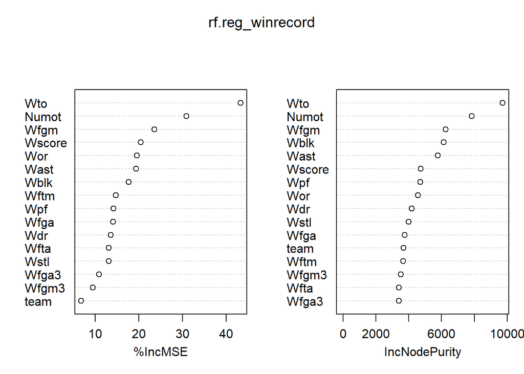

```r
varImpPlot(rf.reg_winrecord)
```

Based on the yearly aggregate data, turnover seems to be the most important variable in determining number of wins

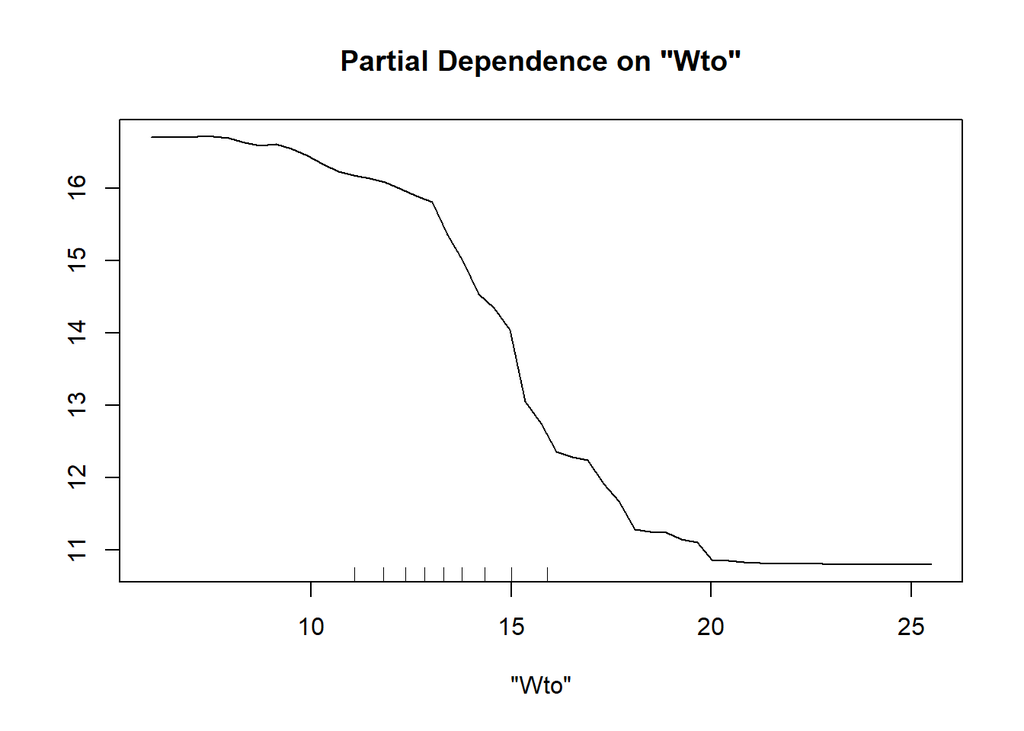

```r
partialPlot(rf.reg_winrecord, reg_winrecord.1, x.var = "Wto")
```

```r
# for (i in ncol(reg_winrecord.1)){
#   partialPlot(rf.reg_winrecord, reg_winrecord.1, x.var = colnames(reg_winrecord.1)[i])
# }
```

##### boosting

```r
#boosting
set.seed(2)
boost.reg_winrecord = gbm(num_wins~. -num_lose-win_rate, data = reg_winrecord.1[train,],
                 distribution = "gaussian",
                 n.trees = 5000,
                 interaction.depth = 6,
                 shrinkage = 0.2,
                 verbose = F)

yhat.boost = predict(boost.reg_winrecord, newdata = reg_winrecord.1[-train,], n.trees = 5000)
mean((yhat.boost - reg_winrecord.test)^2)
```

```
## [1] 24.43974
```

```r
#CV
boost.reg_winrecord.cv = gbm(num_wins~. -num_lose-win_rate ,
                    data = reg_winrecord.1[train,],
                    distribution = "gaussian",
                    n.trees = 5000,
                    interaction.depth = 6,
                    verbose = F,
                    cv.folds = 10)

min(boost.reg_winrecord.cv$cv.error)
```

```
## [1] 20.70042
```

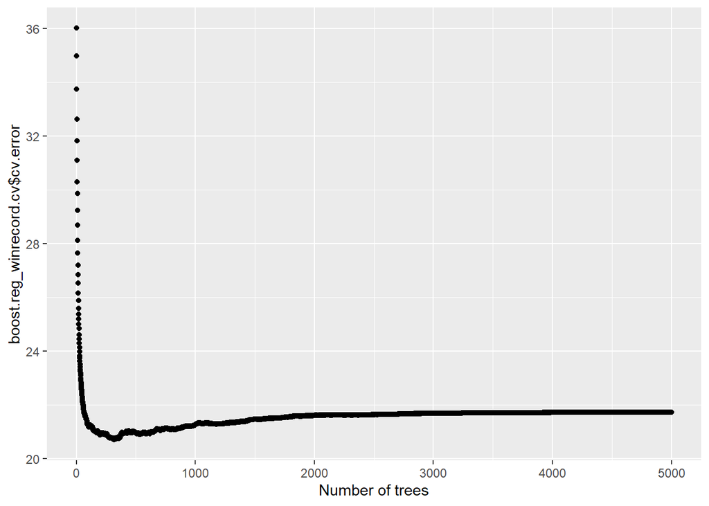

```r
qplot(1:5000, boost.reg_winrecord.cv$cv.error, xlab = "Number of trees")
```

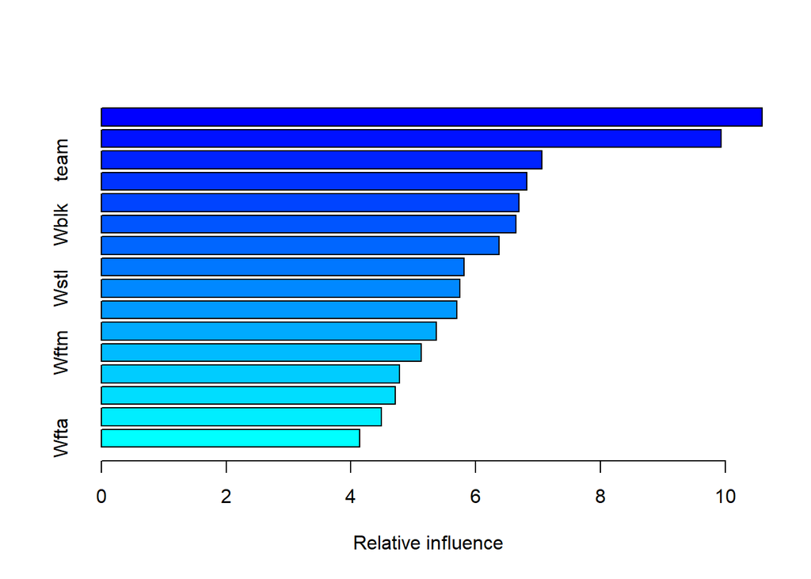

```
##           var   rel.inf
## Numot   Numot 10.591746
## Wto       Wto  9.932256
## team     team  7.065561
## Wast     Wast  6.824174
## Wfgm     Wfgm  6.695392
## Wblk     Wblk  6.646497
## Wor       Wor  6.376088
## Wpf       Wpf  5.813667
## Wstl     Wstl  5.742621
## Wdr       Wdr  5.700656
## Wfga     Wfga  5.373450
## Wftm     Wftm  5.124645
## Wscore Wscore  4.777999
## Wfga3   Wfga3  4.711449
## Wfgm3   Wfgm3  4.486021
## Wfta     Wfta  4.137778
```

```r
summary(boost.reg_winrecord.cv)
```

## Question 2.1: How do teams earn a seat in playoff season? Analyze with aggregated yearly data

The data is similar to question 1.2 with addtional column: tour playoff(1 means the team entered playoff while 0 means the team didn’t)

### Step 1: Data adding

##### Add a column of tour playoff

```r
#add a 1 or 0 to the reg_record
tour <-  c()

for ( year in 2003:2015){

  reg.season <-  reg_winrecord[which(reg_winrecord$year == year),]
  team1 <- unique(tourneystats[which(
    tourneystats$Season == year),]$Wteam)
  team2 <- unique(tourneystats[which(
    tourneystats$Season == year),]$Lteam)
  tour.team <- unique(c(team1, team2))
  for (team in reg.season$team){
    if(team %in% tour.team){
      tour <-  append(tour, 1)
    }else{
      tour <-  append(tour,0)
    }
  }
}
reg_tourrecord <-  cbind(reg_winrecord, tour)
```

##### Merge all the record

```r
#merge the lose and win record

reg_mix <-  merge(reg_tourrecord, reg_loserecord, by = c("team", "year"))


reg_mix <- subset(reg_mix,
                        select  = -c(team,year, h.win.x,a.win.x, n.win.x, Wscore,
                                     num_wins.y,num_lose.y, lose_rate, h.win.y,
                                     a.win.y, n.win.y, Lscore, Numot.y))
sub1 <- reg_mix$num_wins.x * reg_mix[,5:17]
sub2 <- reg_mix$num_lose.x * reg_mix[,19:31]



reg_merge <- cbind((sub1+sub2)/(reg_mix$num_wins.x+reg_mix$num_lose.x),
              reg_mix$tour)


names(reg_merge) <- c("fgm","fga","fgm3","fga3","ftm","fta","or",
                      "dr","ast","to","stl","blk","pf","tour")
```

### Step 2: Exploratory analysis

```r
df <-  reg_winrecord %>%
  select(tour,h.win,win_rate, Wfgm, Wfga, Wfgm3, Wfga3,
         Wftm, Wfta, Wor, Wdr, Wast, Wto, Wstl, Wblk, Wpf)
```

```
## Note: Using an external vector in selections is ambiguous.
## i Use `all_of(tour)` instead of `tour` to silence this message.
## i See <https://tidyselect.r-lib.org/reference/faq-external-vector.html>.
```

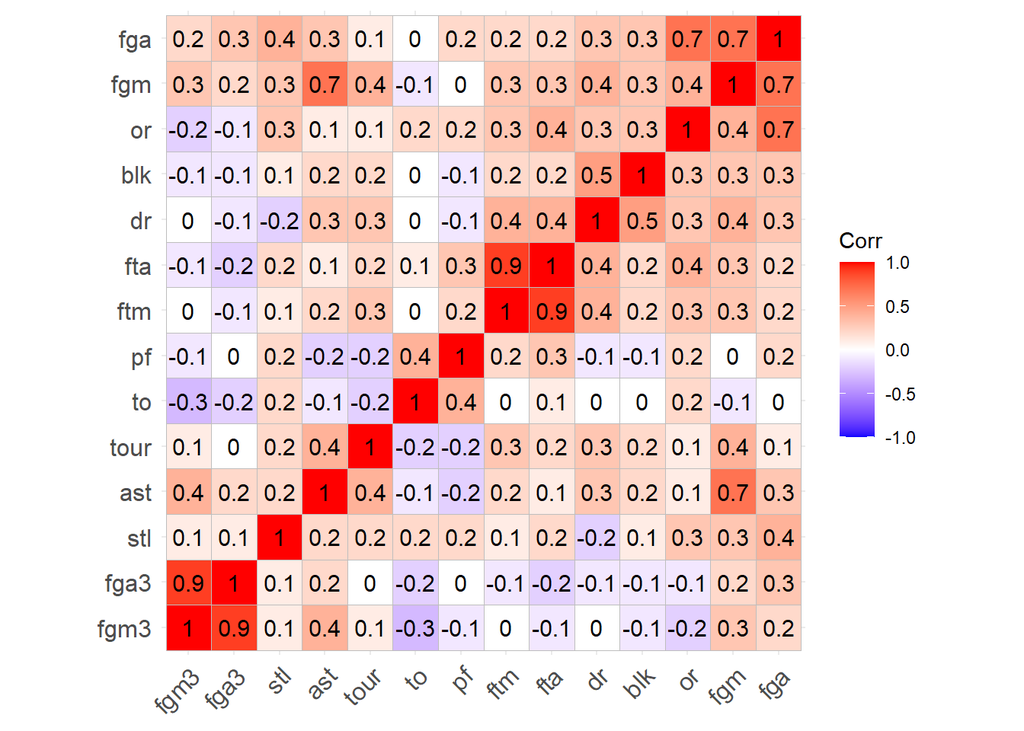

```r
corr <-  round(cor(reg_merge), 1)
ggcorrplot(corr, hc.order = TRUE, lab = TRUE)
```

```r
reg_merge <- subset(reg_merge, select = -c(fga, fga3))
```

fgm and fga, fga3 and fgm3 has high correlation, so they will be removed.

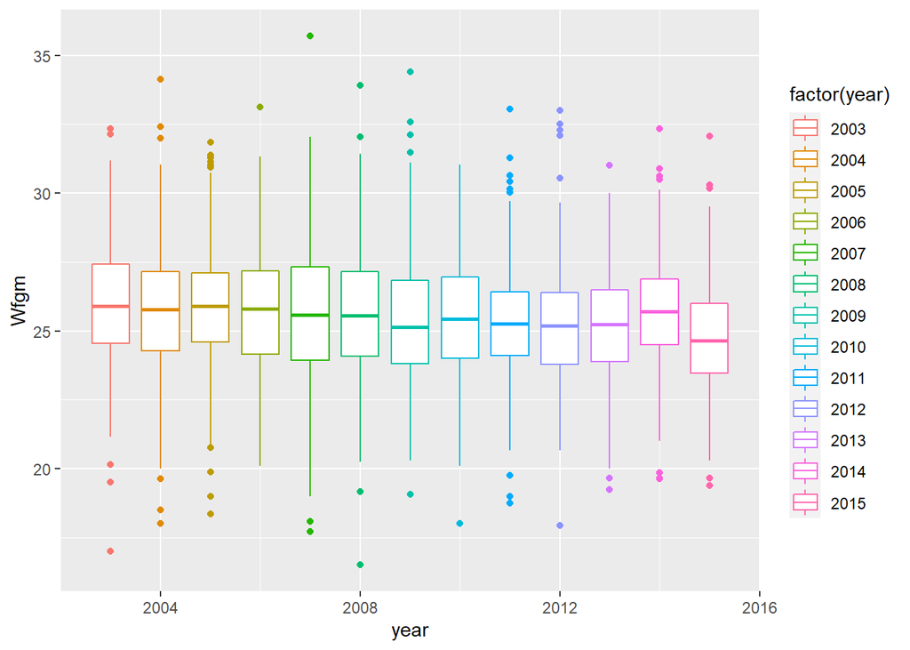

```r
ggplot(data = reg_winrecord, aes(x = year, y = Wfgm, colour = factor(year))) + geom_boxplot(mapping = aes(x = year, y = Wfgm))
```

```r
  geom_jitter()
```

```
## geom_point: na.rm = FALSE
## stat_identity: na.rm = FALSE
## position_jitter
```

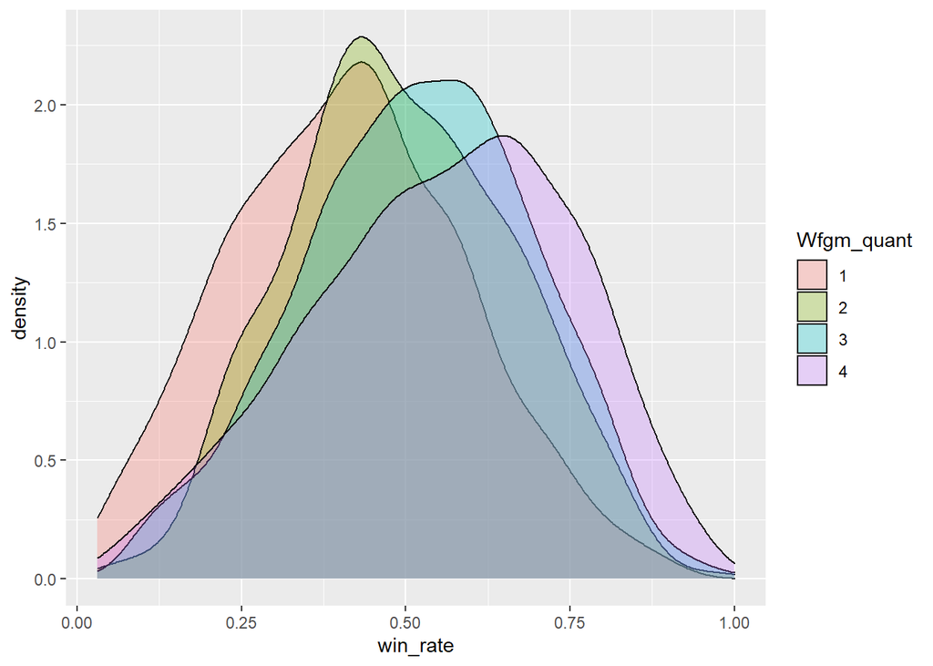

```r
temp = reg_winrecord
temp = temp %>%
        mutate(Wfgm_quant = as.character(ntile(Wfgm, 4)))


d =  ggplot(temp, aes(x = win_rate, fill = Wfgm_quant))
d + geom_density(aes(fill = Wfgm_quant), alpha = 0.3)
```

From color 1-4 they represent teams with different number of winning field goals made. The stronger the team, the more field goals made,the higher the winning rate.

### Step 3: Variable selection

```r
reg.fwd = regsubsets(tour~. , data = reg_merge ,method = "forward")

summary(reg.fwd)
```

```
## Subset selection object
## Call: regsubsets.formula(tour ~ ., data = reg_merge, method = "forward")
## 11 Variables  (and intercept)
##      Forced in Forced out
## fgm      FALSE      FALSE
## fgm3     FALSE      FALSE
## ftm      FALSE      FALSE
## fta      FALSE      FALSE
## or       FALSE      FALSE
## dr       FALSE      FALSE
## ast      FALSE      FALSE
## to       FALSE      FALSE
## stl      FALSE      FALSE
## blk      FALSE      FALSE
## pf       FALSE      FALSE
## 1 subsets of each size up to 8
## Selection Algorithm: forward
##          fgm fgm3 ftm fta or  dr  ast to  stl blk pf
## 1  ( 1 ) "*" " "  " " " " " " " " " " " " " " " " " "
## 2  ( 1 ) "*" " "  " " " " " " " " " " " " " " " " "*"
## 3  ( 1 ) "*" " "  "*" " " " " " " " " " " " " " " "*"
## 4  ( 1 ) "*" " "  "*" " " " " " " "*" " " " " " " "*"
## 5  ( 1 ) "*" " "  "*" " " " " " " "*" "*" " " " " "*"
## 6  ( 1 ) "*" " "  "*" " " " " " " "*" "*" "*" " " "*"
## 7  ( 1 ) "*" " "  "*" " " " " "*" "*" "*" "*" " " "*"
## 8  ( 1 ) "*" " "  "*" " " " " "*" "*" "*" "*" "*" "*"
```

The model above seems to remove fgm3(3 pointers made), fta(free throws attempted), or(offensive rebounds)

### Step 4: Model fits

##### Set train and test

```r
set.seed(1)

idx <- createDataPartition(reg_merge$fgm,p = 0.75, list = FALSE)

reg.train <- reg_merge[idx,]

reg.test  <- reg_merge[-idx,]


reg.train$tour <- as.factor(reg.train$tour)
reg.test$tour <- as.factor(reg.test$tour)
```

##### KNN model

```r
#train model
knn_model <-  train(tour~., data = reg.train,
                    method = "knn",
                    trControl = trainControl(method = "cv",number = 10),
                    tuneGrid = expand.grid(k = seq(1, 50, by = 1)))

best <- which(rownames(knn_model$results) == rownames(knn_model$bestTune))
best_result <- knn_model$results[best,]


#test model
preds.knn <-  predict(knn_model, reg.test)
mean(preds.knn == reg.test$tour)
```

```
## [1] 0.8658205
```

##### GLM model

```r
x <- model.matrix(tour~., reg.train)[,-12]
# Convert the outcome (class) to a numerical variable
y <- reg.train$tour
x.test <- model.matrix(tour~., reg.test)[,-12]
y.test <- reg.test$tour

cv.lasso <- cv.glmnet(x,y, alpha = 1, family = "binomial")
glm.fits <- glmnet(x, y, alpha = 1, family = "binomial",
                lambda = cv.lasso$lambda.min)

#produce a simpler model
coef(cv.lasso, cv.lasso$lambda.1se)
```

```
## 12 x 1 sparse Matrix of class "dgCMatrix"
##                        1
## (Intercept) -11.89750716
## (Intercept)   .
## fgm           0.02529763
## fgm3          .
## ftm           0.14511682
## fta           .
## or            .
## dr            0.29001376
## ast           0.31392607
## to           -0.38466384
## stl           0.24333355
## blk           0.09715161
```

```r
preds.glm <- predict(glm.fits,x.test)
preds.class <-  ifelse(preds.glm > 0.5, 1, 0)
mean(preds.class == y.test)
```

```
## [1] 0.8776065
```

From the simplified model by lasso, fgm(field goals made),ftm(free throw made), dr(defensive rebounds),ast(assists), to(turnovers), blk(blocks) and stl(steals) are selected. This is similar to the forward variable selection method.

##### Random forests

```r
p = 11

bag.reg <- randomForest(tour~., reg.train, mtry = sqrt(p),
                        importance = TRUE)

yhat <- predict(bag.reg, newdata = reg.test)
mean(yhat == reg.test$tour)
```

```
## [1] 0.869447
```

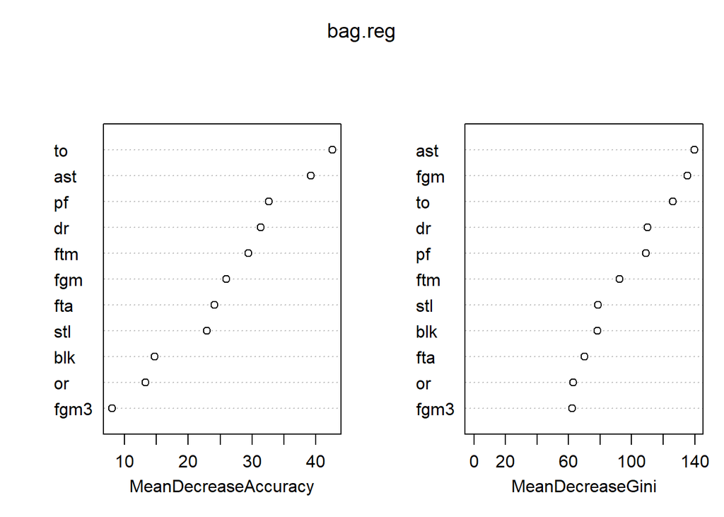

```r
varImpPlot(bag.reg)
```

Apparently, the glm model works the best! Also, turnover and assists are the most important variables. Now teams should consider improve these two aspects to increase their chance of entering playoff season!

## Question 3: Unsupervised learning

##### Hierarchical clustering

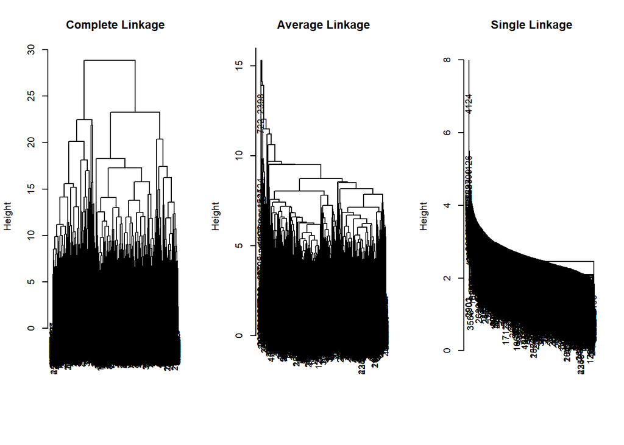

```r
hc.complete <- hclust(dist(reg_merge), method="complete")
hc.average <- hclust(dist(reg_merge), method="average")
hc.single <- hclust(dist(reg_merge), method="single")
par(mfrow=c(1,3))
plot(hc.complete,main="Complete Linkage", xlab="", sub="", cex=.9)
plot(hc.average, main="Average Linkage", xlab="", sub="", cex=.9)
plot(hc.single, main="Single Linkage", xlab="", sub="", cex=.9)
```

complete works better

##### Find the best cut

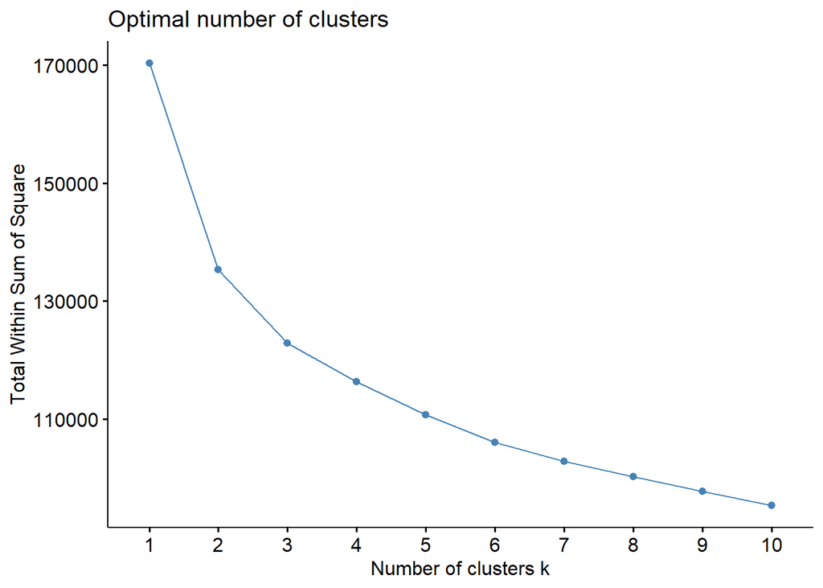

```r
fviz_nbclust(reg_merge,hcut, method = 'wss')
```

##### Cut tree

```r
split <- cutree(hc.complete, 4)
split.bind <- cbind(reg_merge, split)
table.display <- cbind()

for (i in 1:4){
  group <- split.bind[which(split.bind$split == i),]
  print(i)
  print(colMeans(group))
  table.display <- cbind(table.display, colMeans(group))
}
```

```
## [1] 1
##         fgm        fgm3         ftm         fta          or          dr
## 23.21892485  5.98908034 13.89113960 20.28550386 11.29878160 22.84897786
##         ast          to         stl         blk          pf        tour
## 12.26958972 14.54197452  6.60213138  3.16781128 19.12054644  0.08249881
##       split
##  1.00000000
## [1] 2
##        fgm       fgm3        ftm        fta         or         dr        ast
## 23.1296840  6.8069417 12.1597799 17.3977146  9.6701885 21.9378942 13.0257699
##         to        stl        blk         pf       tour      split
## 12.8956411  6.2110524  2.7832286 17.6592281  0.1237624  2.0000000
## [1] 3
##        fgm       fgm3        ftm        fta         or         dr        ast
## 25.6937210  6.5600871 15.1900725 21.8125629 12.0107546 24.3058060 14.2425537
##         to        stl        blk         pf       tour      split
## 13.4968647  6.9447440  3.8966831 18.2310703  0.4087537  3.0000000
## [1] 4
##       fgm      fgm3       ftm       fta        or        dr       ast        to
## 23.664204  5.829393 17.750545 25.596956 12.025556 23.786985 12.208675 15.041892
##       stl       blk        pf      tour     split
##  6.867237  3.370033 20.733495  0.202381  4.000000
```

```r
library(knitr)
kable(table.display, digits = 3)
```

| fgm | 23.219 | 23.130 | 25.694 | 23.664 |
| --- | --- | --- | --- | --- |
| fgm3 | 5.989 | 6.807 | 6.560 | 5.829 |
| ftm | 13.891 | 12.160 | 15.190 | 17.751 |
| fta | 20.286 | 17.398 | 21.813 | 25.597 |
| or | 11.299 | 9.670 | 12.011 | 12.026 |
| dr | 22.849 | 21.938 | 24.306 | 23.787 |
| ast | 12.270 | 13.026 | 14.243 | 12.209 |
| to | 14.542 | 12.896 | 13.497 | 15.042 |
| stl | 6.602 | 6.211 | 6.945 | 6.867 |
| blk | 3.168 | 2.783 | 3.897 | 3.370 |
| pf | 19.121 | 17.659 | 18.231 | 20.733 |
| tour | 0.082 | 0.124 | 0.409 | 0.202 |
| split | 1.000 | 2.000 | 3.000 | 4.000 |

DataSource: https://www.kaggle.com/c/march-machine-learning-mania-2016/rules Citation: Daniel Sun(a crazy basketball fan that gave us some suggestions!)